# ISLR - Chapter 9 Labs

Lars Hadidi und Manuel Herbst

# 1 Support Vector Classifier

# 2 Support Vector Machine

We use an SVM if we want to have a “curved”/ “nonlinear” decision boundary for our classification:

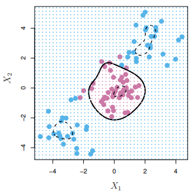

The “nonlinear” decision boundary curve is given by the zeros of a “nonlinear” function of the form
$$f(x) = -\rho + \alpha_1K(x_1,x) + \alpha_2K(x_2,x) + \ldots + \alpha_nK(x_n,x)$$

The kernel map $K$ is either the linear, the polynomial or the radial Kernel.

The predicted class label of an observation $x$ is based on whether $f(x) \geq 0$ or $f(x) < 0$. The value $f(x)$ is referred to as **fitted value** for the observation $x$.

The **margins** are given by the level sets $f = 1$ and by $f = -1$.

A **support vector** is an observation $x_i$ from class $y_i\in \pm 1$ that violates the margin in the sense that $y_if(x_i) \leq 1$. This includes observations on the margin.

For this LAB, We need the following libraries:

- Want to use the **svm()** function:

```r
library(e1071)
```

- Want to plot ROC curves:

```r
library(ROCR)
```

- Want to use the Gene Expression Data set **Khan**

```r
library(ISLR)
```

## 2.1 Data simulation

1. Generate some data with a non-linear class boundary and plot it

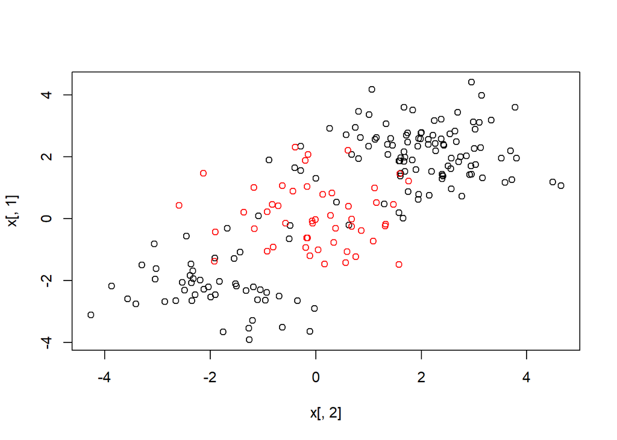

```r
# In order to have reproducable simulated data
set.seed(1)

# We want to have n = 200 observations with p = 2 real-valued normally distributed features
# The first 150 observations shall belong to class 1, the remaining 50 observations shall belong to class 2
y <- c(rep(1, 150), rep(2, 50))
x <- matrix(rnorm(200 * 2), ncol = 2)

# We move the class 1 observations in order to
# distinguish them from class 2 observations
x[1:100, ] <- x[1:100, ] + 2
x[101:150, ] <- x[101:150, ] - 2

# Convert simulated data in a data frame:
dat <- data.frame(x = x, y = as.factor(y))
# Do not forget as.factor()!!
# Class labels need to be a factor variable
# Otherwise: svm()-function performs Support Vector Regression

# Class labels 1 and 2 because of the color:
# 1 = black
# 2 = red
plot(x[,2], x[,1], col = y)
```

2. We randomly choose 100 training observations (training data set). The remaining 100 observations build our test training data set

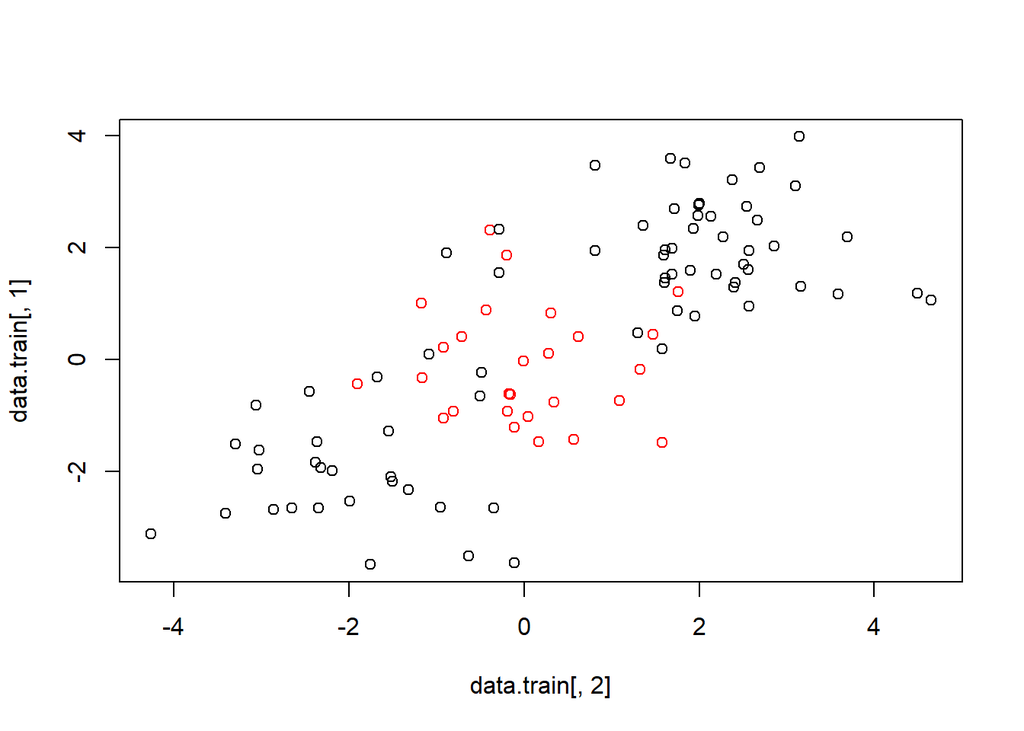

```r
train <- sample(200, 100) # choose 100 out of 200 without replacement

# Training data set
data.train <- dat[train,]

# Test data set
data.test <- dat[-train,]
# The Minus sign reads: leave out all training observations

# Plot the training data:
plot(data.train[,2], data.train[,1] , col = data.train[,3])
```

## 2.2 Training a SVM using svm()

```r
library(e1071)

#?svm()
```

Input arguments (only the most important):

1. **x** and/or **data**: matrix or data frame containing the observed features
2. **y** : vector containing the response values; in our setting: containing the class labels **as factors!!!**
3. **kernel**: specifying the kernel
- Linear Kernel: **kernel = “linear”**,
  $$K(x,y) := \left\langle x,y \right\rangle$$
- Polynomial kernel: **kernel = “polynomial”**,
  $$K(x,y) := (c_0+\gamma\left\langle x,y \right\rangle)^d$$
  also specifying **degree**, **coef0** and **gamma**; default: $d=3$, $c_0 = 0$, $\gamma = (\text{data dimension})^{-1}$
- Radial kernel (RBF): **kernel = “radial”**,
  $$K(x,y) := \exp(-\gamma \left\|x-y\right\|^2)$$

specifying tuning parameter **gamma** $\gamma$.

default: “radial”

4. **cost**: Parameter regulating the Bias-Variance-Tradeoff
- Large cost parameter heavily penalize violations to the margins, result: only few support vectors, narrow margins, very sensitive reaction to outliers (Low-Bias-High-Variance estimator)
- Small cost parameters: many support vectors, wide margins, recognize outliers (High-Bias-Low-Variance estimator)
- default: cost = 1
5. **scale = TRUE**: Scale each feature to have mean zero and unit variance
6. $\textbf{decision.values = TRUE}$: If you need the fitted values $f(x)$ for observations $x$.

Output of svm(): An object of class “svm” containing the fitted model

```r
# Fit a model unsing a radial kernel with gamma = 1 and cost = 1
svm.out <- svm(y ~ ., data = data.train, kernel = "radial", gamma = 1, cost = 1, decision.values = T)

# To obtain some information about the fitted model:
typeof(svm.out)
```

```
## [1] "list"
```

```r
class(svm.out)
```

```
## [1] "svm.formula" "svm"
```

```r
summary(svm.out)
```

```
##
## Call:
## svm(formula = y ~ ., data = data.train, kernel = "radial", gamma = 1,
##     cost = 1, decision.values = T)
##
##
## Parameters:
##    SVM-Type:  C-classification
##  SVM-Kernel:  radial
##        cost:  1
##       gamma:  1
##
## Number of Support Vectors:  37
##
##  ( 17 20 )
##
##
## Number of Classes:  2
##
## Levels:
##  1 2
```

Want to visualize the model:

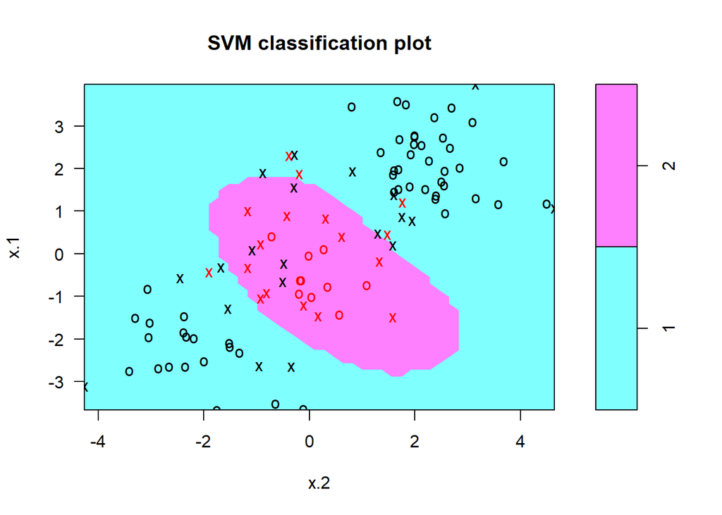

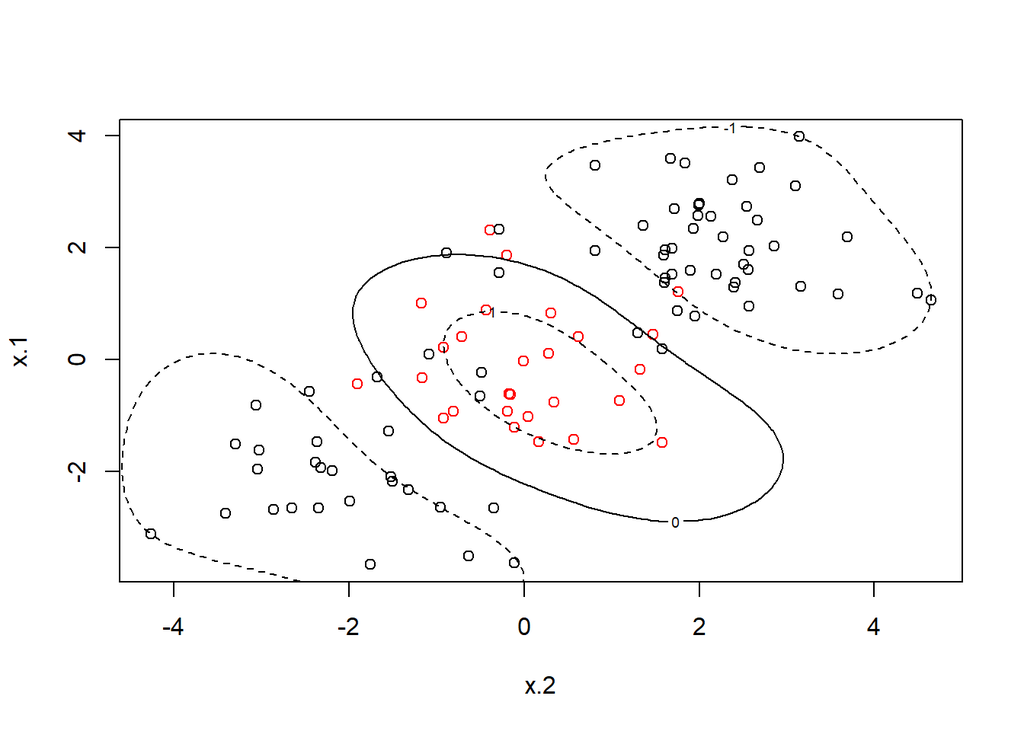

```r
svm.plot <- function(svm.out, data.train){
  # First plot: Decision areas, Support Vectors are represented by a cross
  plot(svm.out, data.train)

  # Second plot: Decision boundary and margins added to the data
  plot(data.train[,c(2,1)], col = data.train[,3])

  # Generating grid points:
  min <- min(data.train[,c(2,1)])
  max <- max(data.train[,c(2,1)])
  x2 <- seq(from = min -1, to = max+1, by = 0.1)
  x1 <- x2
  xgrid <- data.frame(expand.grid(X1=x1,X2=x2))
  names(xgrid) <- names(data.train)[c(2,1)]

  # For each point x of the grid, we determine the fitted value f(x)
  # This enables us to determine the contour lines of f=0, f=1 and f=-1 respectively
  # Note: Applying the function predict() yields only the predicted class labels. On has to set decision.values = TRUE and the fitted values can then be obtained via the attribute() function:
fit <- attributes(predict(svm.out,xgrid, decision.values = T))$decision.values
  f <- matrix(fit,ncol = length(x1))
  # Now we can add the decision boundary and the margins to the data
  contour(x2,x1,f,add=T, levels = 0, lty = 1)
  contour(x2,x1,f,add=T, levels = 1, lty = 2)
  contour(x2,x1,f,add=T, levels = -1, lty = 2)
  #return()
}
# We call the function svm.plot():
svm.plot(svm.out,data.train)
```

In our example, there were 37 support vectors.

Claim: SVM algorithm produces the same decision boundary, using only support vectors.

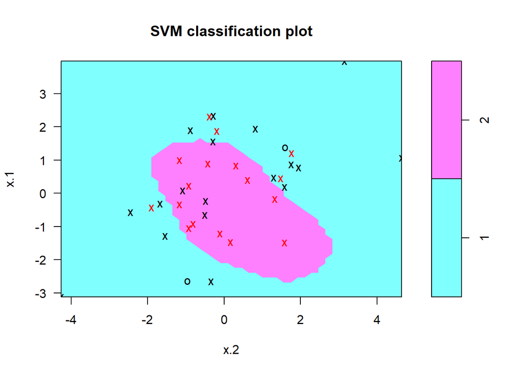

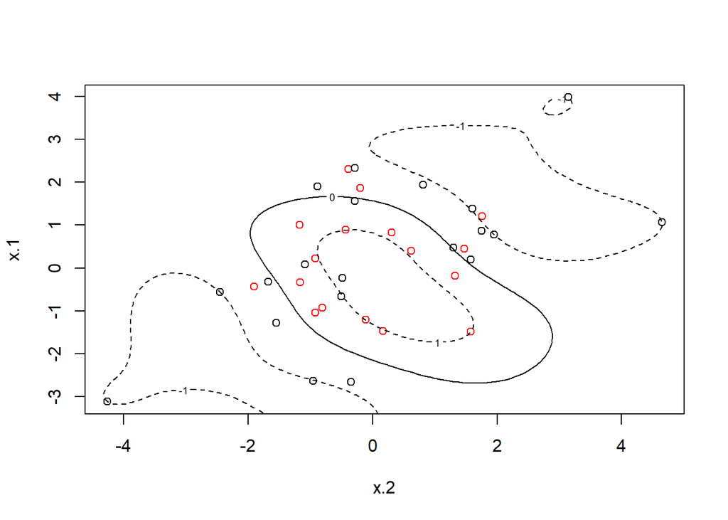

```r
# Which observation is a support vector?
# The support vector indices can be obtained via svm.out$index:
data.sv.only <- data.train[svm.out$index, ]

# SVM using support vectors only
svm.sv.only <- svm(y ~ ., data = data.sv.only, kernel = "radial", gamma = 1, cost = 1, decision.values = T)
svm.plot(svm.sv.only,data.sv.only)
```

Claim: Increasing the **cost** parameter reduces the number of support vectors and margin width at the price of a more irregular decision boundary (risk of overfitting the data):

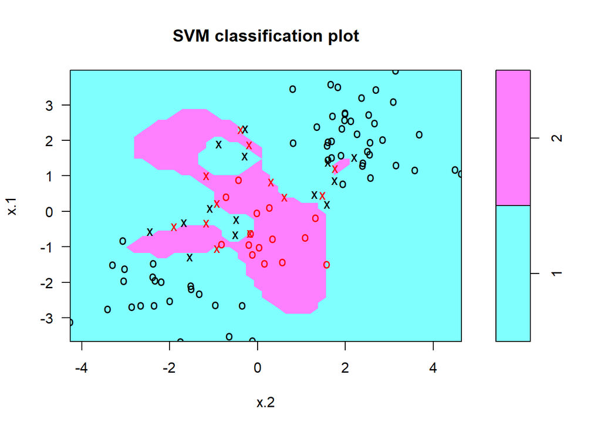

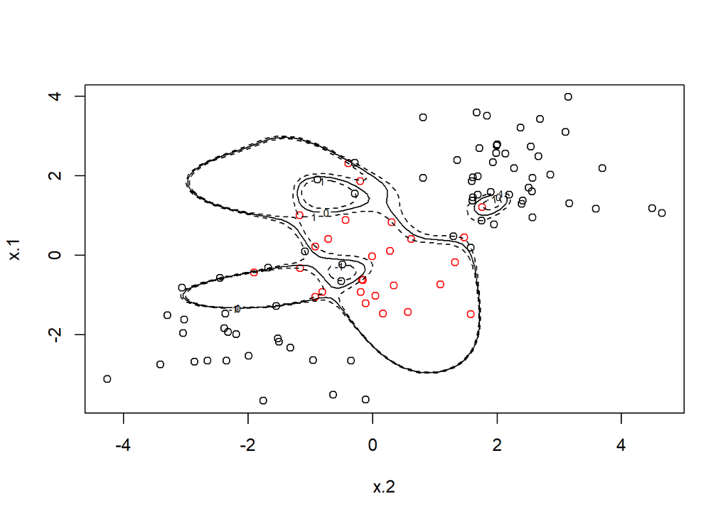

```r
svm.overfit <- svm(y ~ ., data = data.train, kernel = "radial", gamma = 1, cost = 1e5, decision.values = T)
svm.plot(svm.overfit, data.train)
```

With a cost parameter of $10^5$, there were 26 support vectors.

Claim: Increasing the **gamma** parameter yields a more irregular decision boundary with a “local” behaviour (risk of overfitting the data)

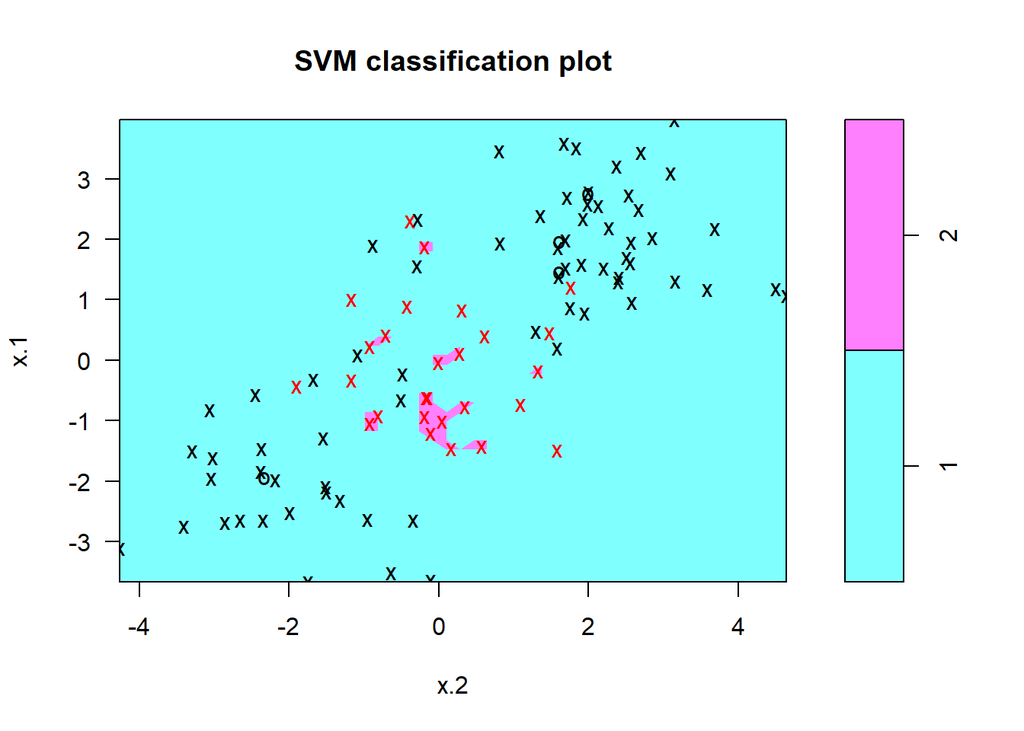

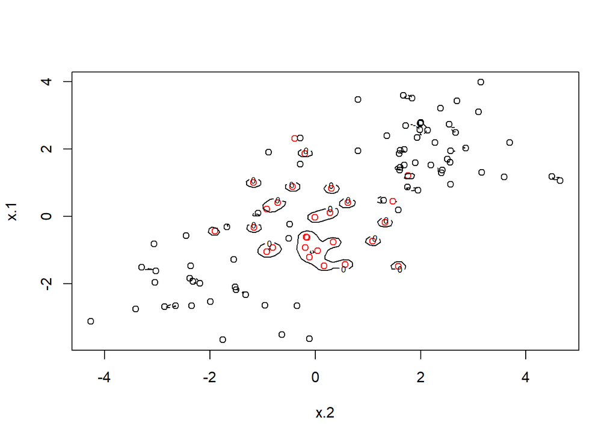

```r
svm.overfit <- svm(y ~ ., data = data.train, kernel = "radial", gamma = 100, cost = 1, decision.values = T)
svm.plot(svm.overfit, data.train)
```

With a gamma parameter of $100$, there were 96 support vectors.

## 2.3 Cross-Validation using the function tune()

Want to perform a 10-fold cross-validation using **tune()** to select the best choice of $\gamma$ and the cost-parameter:

```r
# ?tune()
# ?tune.control()
set.seed(1)
tune.out <- tune(svm, y ~ ., data = data.train, kernel = "radial", ranges = list(cost = c(0.1, 1, 10, 100, 1000), gamma = c(0.5, 1, 2, 3, 4)))
## 25 models
## 10-fold cross-validation: Randomly split data.train into 10 test training data sets of size 10
## For each test data set: The remaining 90 observations are used to train the model. Its test error rate is determined on the test data.
## For each model: We obtain 10 test error rates. Report the average and the standard deviation (referred to sa "dispersion")

## Values of the best parameters: tune.out$best.parameters
## Best model: tune.out$best.model
summary(tune.out)
```

```
##
## Parameter tuning of 'svm':
##
## - sampling method: 10-fold cross validation
##
## - best parameters:
##  cost gamma
##     1     2
##
## - best performance: 0.12
##
## - Detailed performance results:
##     cost gamma error dispersion
## 1  1e-01   0.5  0.27 0.11595018
## 2  1e+00   0.5  0.13 0.08232726
## 3  1e+01   0.5  0.15 0.07071068
## 4  1e+02   0.5  0.17 0.08232726
## 5  1e+03   0.5  0.21 0.09944289
## 6  1e-01   1.0  0.25 0.13540064
## 7  1e+00   1.0  0.13 0.08232726
## 8  1e+01   1.0  0.16 0.06992059
## 9  1e+02   1.0  0.20 0.09428090
## 10 1e+03   1.0  0.20 0.08164966
## 11 1e-01   2.0  0.25 0.12692955
## 12 1e+00   2.0  0.12 0.09189366
## 13 1e+01   2.0  0.17 0.09486833
## 14 1e+02   2.0  0.19 0.09944289
## 15 1e+03   2.0  0.20 0.09428090
## 16 1e-01   3.0  0.27 0.11595018
## 17 1e+00   3.0  0.13 0.09486833
## 18 1e+01   3.0  0.18 0.10327956
## 19 1e+02   3.0  0.21 0.08755950
## 20 1e+03   3.0  0.22 0.10327956
## 21 1e-01   4.0  0.27 0.11595018
## 22 1e+00   4.0  0.15 0.10801234
## 23 1e+01   4.0  0.18 0.11352924
## 24 1e+02   4.0  0.21 0.08755950
## 25 1e+03   4.0  0.24 0.10749677
```

The best parameters are cost = 1 and $\gamma$ = 2.

## 2.4 Predictions using the function predict()

For the best model, we want to view the training and test set predictions using the function **predict()**:

```r
# SVM with best parameter: tune.out$best.model
# True class labels: data.train[,"y"]
# Predicted class label for each test observation: predict() outcome

truth <- data.train[,"y"]
pred <- predict(tune.out$best.model, data.train)
table(truth, pred)
```

```
##      pred
## truth  1  2
##     1 69  4
##     2  5 22
```

Result: 9% of the training data were misclassified.

```r
# The test data set
truth <- data.test[, "y"]
pred <- predict(tune.out$best.model, data.test)
table(truth, pred)
```

```
##      pred
## truth  1  2
##     1 74  3
##     2  7 16
```

Result: 10% of the test data were misclassified.

## 2.5 ROC Curves

We want to assess the predictive power using ROC curves. The fitted values $f(x)$ serve as our continuous predictor for the binary classification.

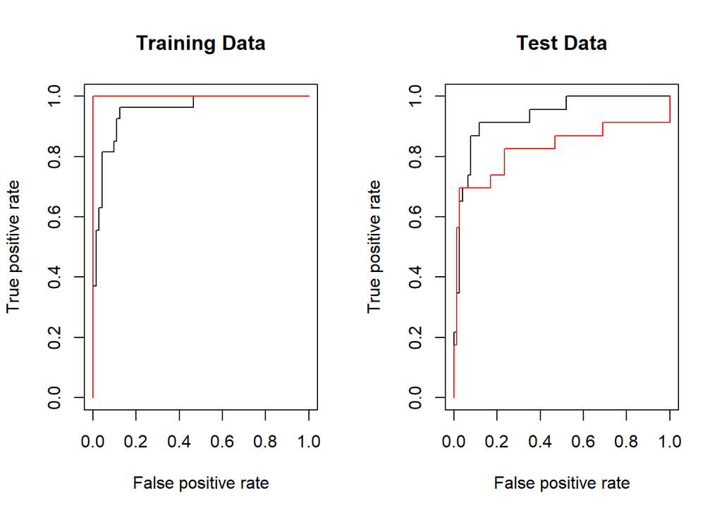

```r
library("ROCR")

# Our best model is tune.out$best.model or
svmfit.opt <- svm(y ~ ., data = data.train, kernel = "radial", gamma = 2, cost = 1, decision.values = T)

# Want to compare this SVM to a highly flexible SVM
svmfit.flex <- svm(y ~ ., data = data.train, kernel = "radial", gamma = 50, cost = 1, decision.values = T)

# Calculate fitted values for training and test data for both models opt and flex
# Note again: Applying the function predict() yields only the predicted class labels. On has to set decision.values = TRUE and the fitted values can then be obtained via the attribute() function:
pred.opt.train <- attributes(predict(svmfit.opt, data.train, decision.values = TRUE))$decision.values
pred.opt.test <- attributes(predict(svmfit.opt, data.test, decision.values = TRUE))$decision.values
pred.flex.train <- attributes(predict(svmfit.flex, data.train, decision.values = TRUE))$decision.values
pred.flex.test <- attributes(predict(svmfit.flex, data.test, decision.values = TRUE))$decision.values

# Save the true class labels
truth.opt.train <- data.train[, "y"]
truth.opt.test <- data.test[, "y"]
truth.flex.train <- data.train[,"y"]
truth.flex.test <- data.test[,"y"]

# Plot the ROC curves using the following function:
rocplot <- function(pred, truth, ...) {
  # For a suitable range of cutoff values t, we have to calculate the true and false positive rates tpr(t) and fpr(t). This is done automatically by the performance() function:
  # Note: The function performance() only takes objects of class "prediction"!

  predob <- prediction(pred, truth)
  perf <- performance(predob, "tpr", "fpr")

  #We then plot tpr(t) against fpr(t).
  plot(perf, ...)
}


par(mfrow = c(1, 2))
rocplot(pred.opt.train, truth.opt.train, main = "Training Data")
rocplot(pred.flex.train, truth.flex.train, add = T, col = "red")
rocplot(pred.opt.test, truth.opt.test, main = "Test Data")
rocplot(pred.flex.test, truth.flex.test, add = T, col = "red")
```

## 2.6 SVM with Multiple Classes

If the response is a factor containing more than two levels, then the svm() function will perform a multi-class classification using the one-versus-one approach:

Suppose, we are in a $M$-class setting with $M>2$.

**One-Versus-One Classification** (Pairwise classification):

- perform classification for all $\left(^{M}_{2}\right)$ pairs
- classifiy a test observation using each of the $\left(^{M}_{2}\right)$ classifiers, tally the number of times that the test observation is assigned to each of the $M$ classes and assign the test observation to the class which it was most frequently assigned to in the pairwise classifications.

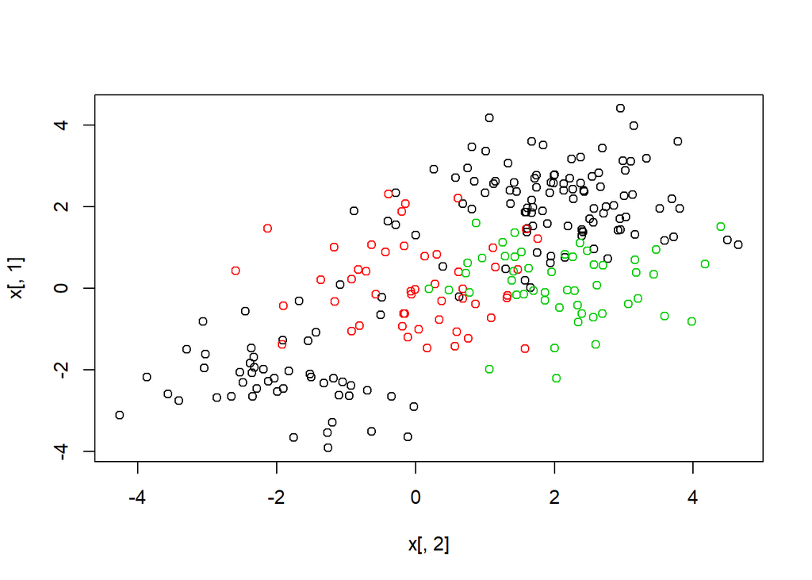

```r
set.seed(1)
# We add 50 observations of our two real-valued features blong to a third class 3:
y <- c(y, rep(3, 50))
x <- rbind(x, matrix(rnorm(50 * 2), ncol = 2))

# We move our class 3 observations in order to distinguish them from class 1 and class 2 observations:
x[y == 3, 2] <- x[y == 3, 2] + 2

# Convert simulated data in a data frame
dat <- data.frame(x = x, y = as.factor(y))

# Plot the data
par(mfrow = c(1, 1))
plot(x[,2],x[,1], col = y )
```

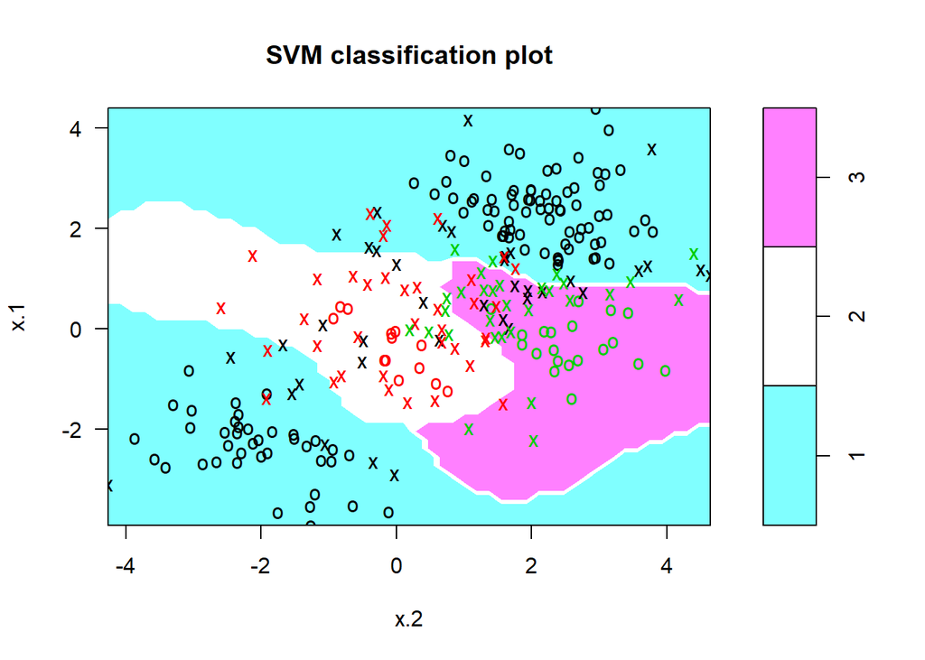

```r
# Fit an SVM to the data using again RBF with cost = 10 and gamma =1:
svm.out <- svm(y ~ ., data = dat, kernel = "radial", cost = 10, gamma = 1)
# Plot the model
# Note: svm.plot is not written for multi-class SVMs!
plot(svm.out, dat)
```

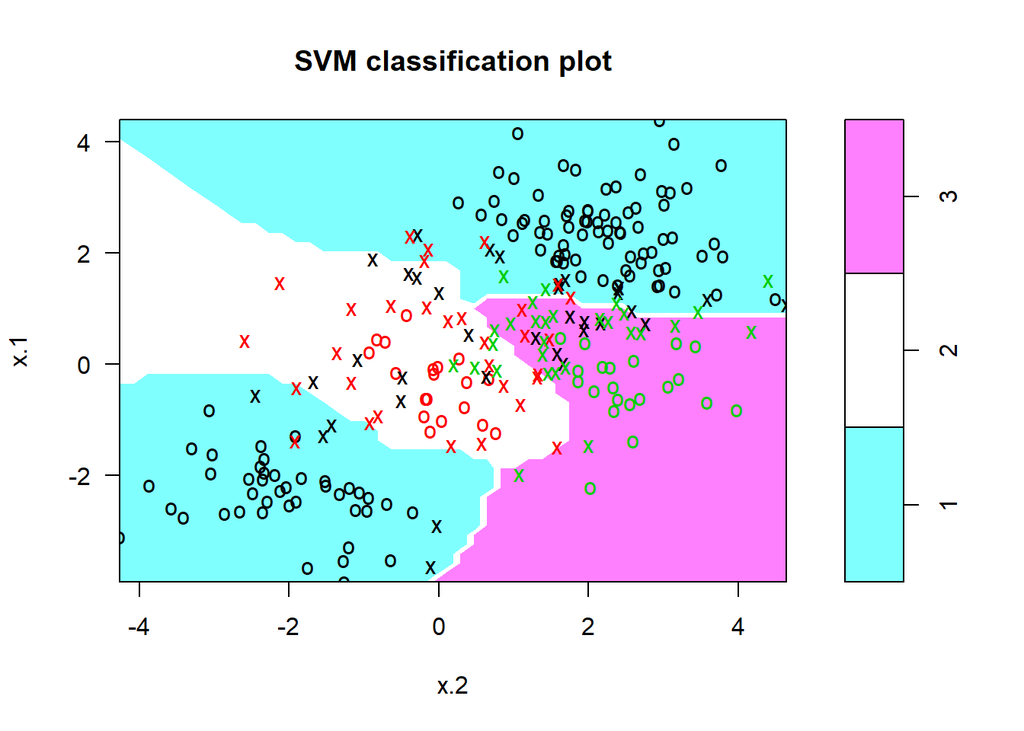

```r
# Compare this to an SVM using a polynomial kernel:
tune.out <- tune(svm, y ~ ., data = dat, kernel = "polynomial", cost = 10, coef0 = 1, gamma = 1,ranges = list(degree = 1:5))
svm.out <- tune.out$best.model
plot(svm.out, dat)
```

# 3 Application to Gene Expression Data

The Khan data set consists of a number of tissue samples corresponding to four distinct types of small round blue cell tumors (denoted by 1,2,3,4). For each tissue sample (observation), $p = 2.308$ gene expression measurements are available. There are $n= 83$ tissue samples split into $63$ training and $20$ test observations.

```r
library("ISLR")

typeof(Khan)
```

```
## [1] "list"
```

```r
class(Khan)
```

```
## [1] "list"
```

```r
names(Khan)
```

```
## [1] "xtrain" "xtest"  "ytrain" "ytest"
```

```r
# Dimension of training observations:
dim(Khan$xtrain)
```

```
## [1]   63 2308
```

```r
# Dimension of test observations:
dim(Khan$xtest)
```

```
## [1]   20 2308
```

```r
# Number of training labels:
length(Khan$ytrain)
```

```
## [1] 63
```

```r
# Number of test labels:
length(Khan$ytest)
```

```
## [1] 20
```

```r
# Tumor frequencies in training data:
table(Khan$ytrain)
```

```
##
##  1  2  3  4
##  8 23 12 20
```

```r
# Tumor frequencies in the test data:
table(Khan$ytest)
```

```
##
## 1 2 3 4
## 3 6 6 5
```

**Discussion**: Based on these information, what type of kernel would you choose in order to fit a 4-class SVM classifier on the training data? Linear? Polynomial? Radial?

```r
# Data frames for training and test data:
data.train <- data.frame(x = Khan$xtrain, y = as.factor(Khan$ytrain))
data.test <- data.frame(x = Khan$xtest, y = as.factor(Khan$ytest))

# Fit a linear SVM!
# Why linear?
# Only few observations in high-dimensional feature space (p >> n)
# Consequence: It is very likely that there are four distinct (p-1)-dimensional hyperplanes each containing the observations of exactly one class (This is not true e.g. if all observations are on a single line)
# In this case: It is easy to find another four distinct hyperplanes separating one class from another
# Additional flexibility provided by non-linear kernels unnecessary
# Linear Kernel yields an estimator with low bias and low variance!
svm.out <- svm(y ~ ., data = data.train, kernel = "linear", cost = 10)
summary(svm.out)
```

```
##
## Call:
## svm(formula = y ~ ., data = data.train, kernel = "linear", cost = 10)
##
##
## Parameters:
##    SVM-Type:  C-classification
##  SVM-Kernel:  linear
##        cost:  10
##       gamma:  0.0004332756
##
## Number of Support Vectors:  58
##
##  ( 20 20 11 7 )
##
##
## Number of Classes:  4
##
## Levels:
##  1 2 3 4
```

```r
# Training errors
pred.train <- predict(svm.out, data.train)
truth.train <- data.train[, "y"]
table(pred.train, truth.train)
```

```
##           truth.train
## pred.train  1  2  3  4
##          1  8  0  0  0
##          2  0 23  0  0
##          3  0  0 12  0
##          4  0  0  0 20
```

```r
# Test errors
pred.test <- predict(svm.out, data.test)
truth.test <- data.test[,"y"]
table(pred.test, truth.test)
```

```
##          truth.test
## pred.test 1 2 3 4
##         1 3 0 0 0
##         2 0 6 2 0
##         3 0 0 4 0
##         4 0 0 0 5
```

There were 0 misclassifications in the training data and 2 misclassifications in the test data.